# Final Project

Michael Kazierad, Suyash Nepal, Max Overmier

5/18/2020

[figure not shown]

[figure not shown]

## The Goal

Our goal is compare FIFA19 game statistics to the real 18/19 match statistics. FIFA19’s statistics are based on the 17/18 real season, so we are going to test how well FIFA19 can predict the outcome of the season following its release (18/19 season).

## Motivation

As a group, we wanted to do a project that would directly address one of society’s biggest questions… “Are video games actually good for something”? There is a lot of controversy over the topic because one side believes that video games “rot the brain” and yield no significant benefit to the player, while the other side believes that video games can be an outlet for creativity and imagination. Our group personally believes that video games are a must in this world (being biased of course since we were born and raised with them and still continue to play them), however, our personal beliefs may not be enough to convince someone else that video games are essential to society. We don’t plan on making a radical video game hater into a video game devotee, but we do plan on chipping away at the argument, even if it is only about one aspect.

The project below will show you how to do this step by step, all links for important vernacular in the soccer industry are listed below, along with resources to help you understand things that are going on in the code that aren’t so obvious. I hope you’re ready to impress your friends, because this will be a *game* changer.

## Data Curation and Parsing

1. Read CSV file for the 18/19 season from the Github repository
2. Add a column to denote the winner of each game by reading the FTR (Full-Time Results)
   - Soccer statistic syntax can be found [HERE](https://github.com/woobe/footballytics/blob/master/data/notes.txt)
   - Guide on how each of these statistics are calculated can be found [HERE](https://ihsaa-static.s3.amazonaws.com/soccer/soccerstatmanual.pdf)
3. Put home team as winner if value of FTR is “H”, or away team as winner if value is “A”
4. Select only the division, home team, away team, and winner columns which will be needed later.
5. Repeat this process on all 5 dataframes for the 5 leagues.
6. Read CSV file for the FIFA19 game data.
7. Shown below is an example of what the League and FIFA data frames look like.

```r
library(tidyverse)

#Step (1)

ENG_df <- read_csv("https://raw.githubusercontent.com/mdkaz/mdkaz.github.io/master/English.csv") %>%
  data.frame()

#Steps (2, 3)

ENG_df <- ENG_df %>% mutate(Winner = ifelse(FTR == "H", HomeTeam, AwayTeam))

#Step (4)

ENG_df <- ENG_df %>% select(Div, HomeTeam, AwayTeam, Winner)

#Step (5)

FRA_df <- read_csv("https://raw.githubusercontent.com/mdkaz/mdkaz.github.io/master/French.csv") %>%
  data.frame() %>%
  mutate(Winner = ifelse(FTR == "H", HomeTeam, AwayTeam)) %>%
  select(Div, HomeTeam, AwayTeam, Winner)

GER_df <- read_csv("https://raw.githubusercontent.com/mdkaz/mdkaz.github.io/master/German.csv") %>%
  data.frame() %>%
  mutate(Winner = ifelse(FTR == "H", HomeTeam, AwayTeam)) %>%
  select(Div, HomeTeam, AwayTeam, Winner)

ITA_df <- read_csv("https://raw.githubusercontent.com/mdkaz/mdkaz.github.io/master/Italian.csv") %>%
  data.frame() %>%
  mutate(Winner = ifelse(FTR == "H", HomeTeam, AwayTeam)) %>%
  select(Div, HomeTeam, AwayTeam, Winner)

SPA_df <- read_csv("https://raw.githubusercontent.com/mdkaz/mdkaz.github.io/master/Spanish.csv") %>%
  data.frame() %>%
  mutate(Winner = ifelse(FTR == "H", HomeTeam, AwayTeam)) %>%
  select(Div, HomeTeam, AwayTeam, Winner)

#Step (6)
#Read csv file for FIFA19 which contains all of the player ratings needed to find an overall team rating

FIFA_df <- read_csv("https://raw.githubusercontent.com/mdkaz/mdkaz.github.io/master/FIFA_data.csv") %>% data.frame()

#Step (7)

head(ENG_df, 10)
```

```
##    Div                HomeTeam               AwayTeam            Winner
## 1   E0       Manchester United         Leicester City Manchester United
## 2   E0             Bournemouth           Cardiff City       Bournemouth
## 3   E0                  Fulham         Crystal Palace    Crystal Palace
## 4   E0       Huddersfield Town                Chelsea           Chelsea
## 5   E0        Newcastle United      Tottenham Hotspur Tottenham Hotspur
## 6   E0                 Watford Brighton & Hove Albion           Watford
## 7   E0 Wolverhampton Wanderers                Everton           Everton
## 8   E0                 Arsenal        Manchester City   Manchester City
## 9   E0               Liverpool        West Ham United         Liverpool
## 10  E0             Southampton                Burnley           Burnley
```

```r
head(FIFA_df, 10)
```

```
##    X1     ID              Name Age Nationality Overall Potential
## 1   0 158023          L. Messi  31   Argentina      94        94
## 2   1  20801 Cristiano Ronaldo  33    Portugal      94        94
## 3   2 190871         Neymar Jr  26      Brazil      92        93
## 4   3 193080            De Gea  27       Spain      91        93
## 5   4 192985      K. De Bruyne  27     Belgium      91        92
## 6   5 183277         E. Hazard  27     Belgium      91        91
## 7   6 177003         L. Modric  32     Croatia      91        91
## 8   7 176580         L. Suárez  31     Uruguay      91        91
## 9   8 155862      Sergio Ramos  32       Spain      91        91
## 10  9 200389          J. Oblak  25    Slovenia      90        93
##                   Club   Value  Wage
## 1         FC Barcelona \200110.5M \200565K
## 2             Juventus    \20077M \200405K
## 3  Paris Saint-Germain \200118.5M \200290K
## 4    Manchester United    \20072M \200260K
## 5      Manchester City   \200102M \200355K
## 6              Chelsea    \20093M \200340K
## 7          Real Madrid    \20067M \200420K
## 8         FC Barcelona    \20080M \200455K
## 9          Real Madrid    \20051M \200380K
## 10     Atlético Madrid    \20068M  \20094K
```

## Entity Resolution Function

- The names of each club that are listed on the real season datasets and within the FIFA dataset sometimes slightly differ in name. This is because many of the club names in the real season dataset are in Latin1 encoding rather than UTF-8 encoding, and therefore perceived as inequal.
  - In order to successfully match these clubs, there is a need for some entity resolution.
- Entity Resolution:
  - The matching of entities based on a similarity threshold. Sometimes entities will have slightly different names or values on two different datasets even though they are referring to the same entity. Entity resolution allows for these entities to be matched even if they are not perfectly identical.
- This particular entity resolution uses the adist() function as part of the RecordLinkage package. This function finds the distance between two character vectors.
- This distance is called the Levenshtein distance.
  - More can be found about this function [HERE](https://stat.ethz.ch/R-manual/R-patched/library/utils/html/adist.html)
- In some cases the adist() function still does not work. In order to manually change the encoding the iconv() function can be used.
  - More info on iconv() function can be found [HERE](https://www.rdocumentation.org/packages/base/versions/3.6.2/topics/iconv)

```r
library(RecordLinkage)

club_similarity <- function(c1, c2){
  club1 <- as.character(c1)
  club1_encode <- iconv(club1, from="latin1", to="UTF-8")
  club2 <- as.character(c2)

  if(is.na(adist(club1, club2)[[1]])){
    if(club1_encode == club2){
      similarity <- TRUE
    } else{
      similarity <- FALSE
    }
  } else if (adist(club1, club2)[[1]] == 1){
    similarity <- TRUE
  } else{
    similarity <- FALSE
  }
  return(similarity)
}
```

## Data Management and Data Cleaning

1. Combine all of the previously created csv files to have a full 18/19 season containing the 5 leagues.
2. Go through matches and count the number of wins and total number of games played by each club.
3. Each league has their own specific number of games played per season. Count the number of games played by each club.
   - More information about games per season can be found [HERE](https://entertainment.howstuffworks.com/soccer.htm) and [HERE](http://dearsportsfan.com/2015/02/19/european-club-soccer-work/)
4. Divide the number of games won by the total number of games played in a season and multiply by 100 to find the season win percentage.
5. Go through FIFA dataframe to find the average rating of each club by taking the mean of the overall rating of each player for each club.
   - Information on how FIFA obtains their ratings can be found [HERE](https://www.goal.com/en-ae/news/fifa-player-ratings-explained-how-are-the-card-number-stats/1hszd2fgr7wgf1n2b2yjdpgynu)
6. Make a new dataframe containg only the clubs and their corresponding team rating.
7. Combine the real season win percentages with the team ratings from FIFA using a left join on the seasonal data.
8. Perform entity resolution on any of the entities that did not match properly in the left join
   - Join is performed before entity resolution to improve efficiency. This prevents the need to perform entity resolution on entities that successfully matched
9. Recombine the dataframes using the left join with updated club names
10. Create a new dataframe containing each players individual ratings, their clubs winning percentage, the players wage, adn the players age.

```r
#Step (1)
#This can only be done since all of the columns of each of the consituent dataframes have the same columns
#Rename the division titles by their league

SZN_df <- rbind(ENG_df, FRA_df, GER_df, ITA_df, SPA_df) %>%
  rename(Club = Winner)
SZN_df$Div <- gsub("E0", "Premier League", SZN_df$Div)
SZN_df$Div <- gsub("D1", "Bundesliga", SZN_df$Div)
SZN_df$Div <- gsub("F1", "Ligue 1", SZN_df$Div)
SZN_df$Div <- gsub("I1", "Serie A", SZN_df$Div)
SZN_df$Div <- gsub("SP1", "La Liga", SZN_df$Div)

#Step (2)
#Count function gives a count of each unique value in the inputted column.

win_perc <- count(SZN_df, SZN_df$Club) %>%
  rename(Club="SZN_df$Club")

home <- count(SZN_df, SZN_df$HomeTeam)
away <- count(SZN_df, SZN_df$AwayTeam)

#Step (3)
#Convert count column from factor to numeric.
#Since each club plays either 17 or 19 games the column is formatted as a factor, which cannot be added together.
#Statement says that if the current value of the column is the factor level "17" then replace the value with the numeric 17, otherwise replace the value with numeric 19.

home$n <- ifelse(home$n %in% c("17"), 17, 19)
away$n <- ifelse(away$n %in% c("17"), 17, 19)

#Step (4)
#Add column of the summed away and home games played to find the total games played by each team.
#Convert the columns into matrices before adding.
#Convert the numbers to doubles when dividing to avoid truncating the value.
#Then multiply by 100 to give total season win percentge for each club.

win_perc <- win_perc %>%
  mutate(games_played = (as.matrix(home$n) + as.matrix(away$n))) %>%
  mutate(perc = as.double(n/games_played) * 100) %>%
  left_join(SZN_df, by="Club") %>%
  select(Div, Club, perc) %>%
  unique()

head(win_perc, 10)
```

```
## # A tibble: 10 x 3
##    Div            Club                       perc
##    <chr>          <chr>                     <dbl>
##  1 Bundesliga     "1. FC N\xfcrnberg"        17.6
##  2 Bundesliga     "1. FSV Mainz 05"          41.2
##  3 Ligue 1        "Amiens SC"                39.5
##  4 Ligue 1        "Angers SCO"               44.7
##  5 Premier League "Arsenal"                  65.8
##  6 Ligue 1        "AS Monaco"                36.8
##  7 Ligue 1        "AS Saint-\xc9tienne"      68.4
##  8 Serie A        "Atalanta"                 63.2
##  9 La Liga        "Athletic Club de Bilbao"  50
## 10 La Liga        "Atl\xe9tico Madrid"       76.3
```

```r
#Step (5)
#Group the dataframe by clubs and then average each players overall rating.

FIFA_df <- FIFA_df %>%
  group_by(Club) %>%
  mutate(team_rating = mean(Overall)) %>%
  ungroup()

#Step (6)
#Remove missing values from the dataset to avoid errors in entity resolution

FIFA_rating <- unique(FIFA_df[, c("Club", "team_rating")])
FIFA_rating <- FIFA_rating[complete.cases(FIFA_rating), ]

head(FIFA_rating, 10)
```

```
## # A tibble: 10 x 2
##    Club                team_rating
##    <chr>                     <dbl>
##  1 FC Barcelona               78.0
##  2 Juventus                   82.3
##  3 Paris Saint-Germain        77.4
##  4 Manchester United          77.2
##  5 Manchester City            76.7
##  6 Chelsea                    76.8
##  7 Real Madrid                78.2
##  8 Atlético Madrid            75.1
##  9 FC Bayern München          77
## 10 Tottenham Hotspur          76.7
```

```r
#Step (7)

team_combined <- win_perc %>%
  left_join(FIFA_rating, by="Club") %>%
  select(Div, Club, perc, team_rating) %>%
  unique()

#Step (8)
#Check for any rows with missing values and perform entity resolution to update club name with corresponding entity within the FIFA dataset.

missing_entities <- !complete.cases(team_combined)
for(row in 1:nrow(team_combined)){
  if(missing_entities[row] == TRUE){
    for(f_row in 1:nrow(FIFA_rating)){
      if (club_similarity(team_combined[row, 1], FIFA_rating[f_row, 1])){
        team_combined[row, "Club"] = FIFA_rating[f_row, "Club"]
      }
    }
  }
}

#Step (9)
#Get rid of any rows that were still not sucessfully linked within the entity resolution

team_combined <- team_combined %>%
  left_join(FIFA_rating, by = "Club") %>%
  rename(team_rating = team_rating.y) %>%
  select(Div, Club, perc, team_rating)
team_combined <- team_combined[complete.cases(team_combined),]

head(team_combined, 10)
```

```
## # A tibble: 10 x 4
##    Div            Club                     perc team_rating
##    <chr>          <chr>                   <dbl>       <dbl>
##  1 Bundesliga     1. FSV Mainz 05          41.2        70.8
##  2 Ligue 1        Amiens SC                39.5        69.1
##  3 Ligue 1        Angers SCO               44.7        70
##  4 Premier League Arsenal                  65.8        75.2
##  5 Ligue 1        AS Monaco                36.8        72.9
##  6 Serie A        Atalanta                 63.2        72.6
##  7 La Liga        Athletic Club de Bilbao  50          73.8
##  8 Bundesliga     Bayer 04 Leverkusen      58.8        75.8
##  9 Serie A        Bologna                  47.4        73.0
## 10 Bundesliga     Borussia Dortmund        82.4        75.3
```

```r
#Step (10)
#club_list is a list of all the matching entities that we found during entity resolution
#Two left joins are performed in order to get the correct club data and then the age and wage of the players

club_list <- as.vector(team_combined$Club)
player_combined <- FIFA_df %>%
  filter(Club %in% club_list) %>%
  left_join(team_combined, by="Club") %>%
  select(Div, Club, Name, Overall, perc, Wage) %>%
  left_join(FIFA_df, by="Name") %>%
  select(Div, Club=Club.x, Name, Rating=Overall.x, perc, Wage=Wage.x, Age) %>%
  as.data.frame()

#This is performed in order to convert the character column of wages as Euros per thousand to an integer value.
player_combined$Wage <- as.numeric(substring(player_combined$Wage, 2, nchar(player_combined$Wage)-1))

head(player_combined, 10)
```

```
##               Div                Club              Name Rating     perc Wage
## 1         La Liga        FC Barcelona          L. Messi     94 84.21053  565
## 2         Serie A            Juventus Cristiano Ronaldo     94 78.94737  405
## 3         Ligue 1 Paris Saint-Germain         Neymar Jr     92 81.57895  290
## 4  Premier League   Manchester United            De Gea     91 57.89474  260
## 5  Premier League     Manchester City      K. De Bruyne     91 89.47368  355
## 6  Premier League             Chelsea         E. Hazard     91 63.15789  340
## 7         La Liga         Real Madrid         L. Modric     91 65.78947  420
## 8         La Liga        FC Barcelona         L. Suárez     91 84.21053  455
## 9         La Liga        FC Barcelona         L. Suárez     91 84.21053  455
## 10        La Liga        FC Barcelona         L. Suárez     91 84.21053  455
##    Age
## 1   31
## 2   33
## 3   26
## 4   27
## 5   27
## 6   27
## 7   32
## 8   31
## 9   22
## 10  20
```

## Exploratory Data Analysis

During exploratory data analysis we begin to visualize our previously cleaned data to see if there are any interesting correlations that we can draw.

Let’s make one plot for each of the 5 leagues we are looking at.

- Each plot has the corresponding club teams on the x axis and the club’s corresponding player ratings on the y axis.
- The plots use a violin distribution to see the distribution of the team’s player ratings

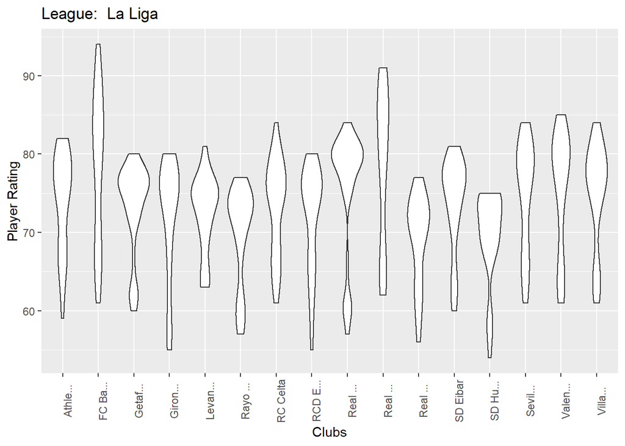

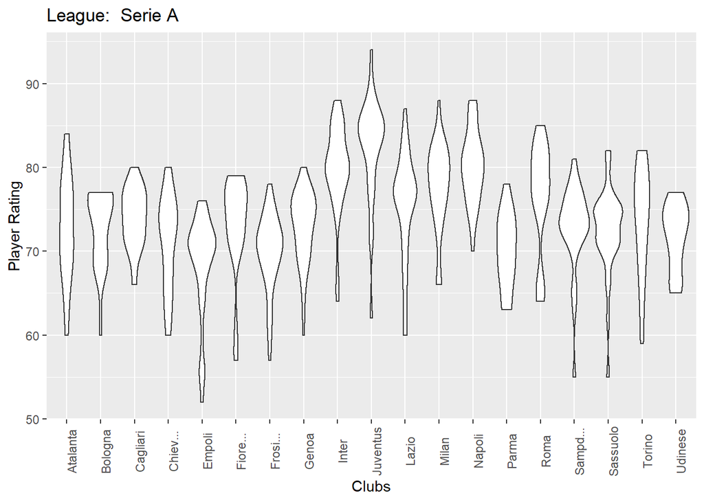

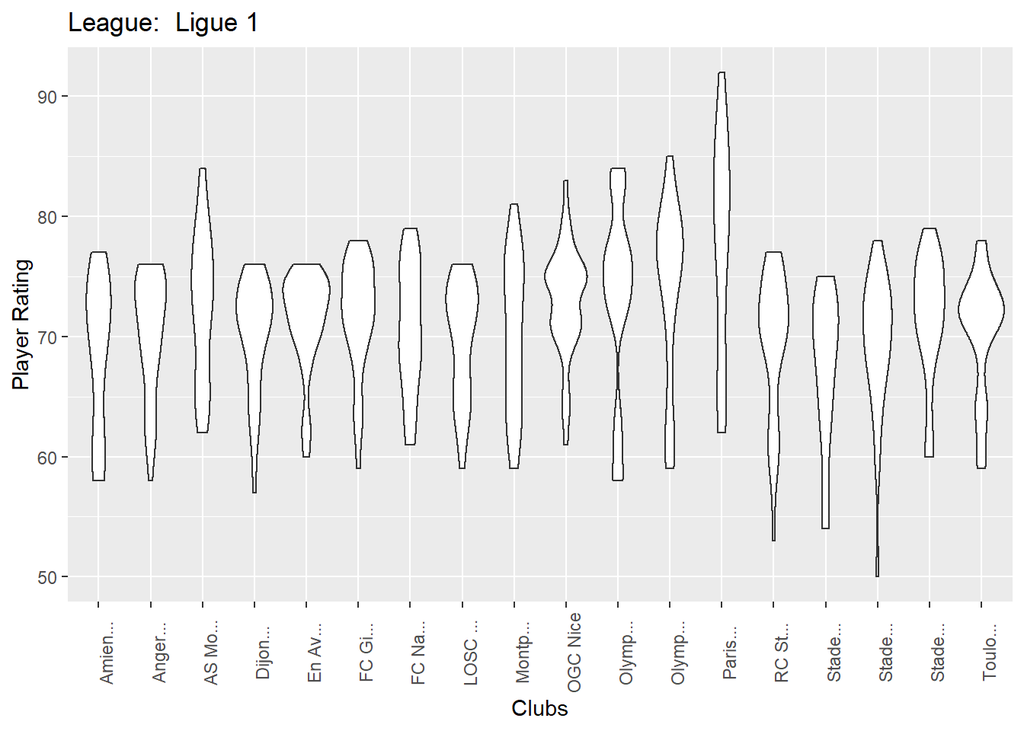

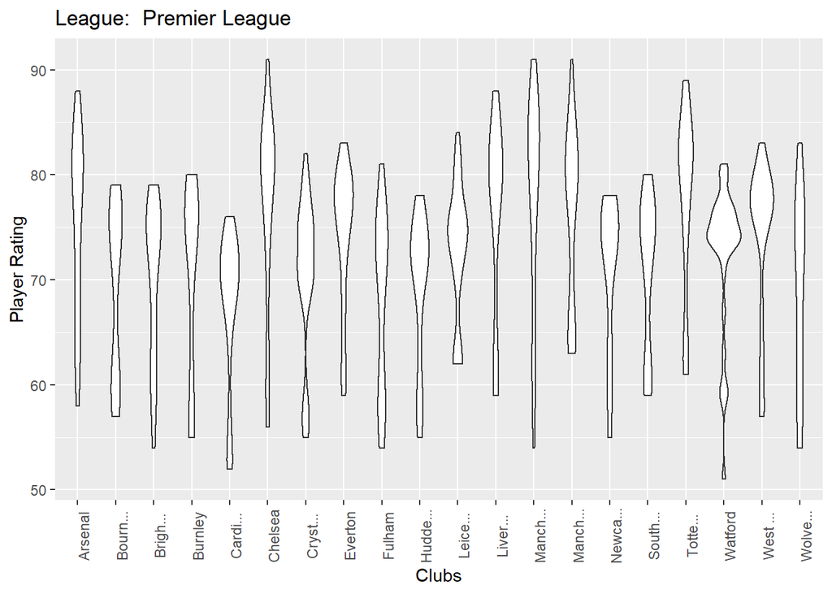

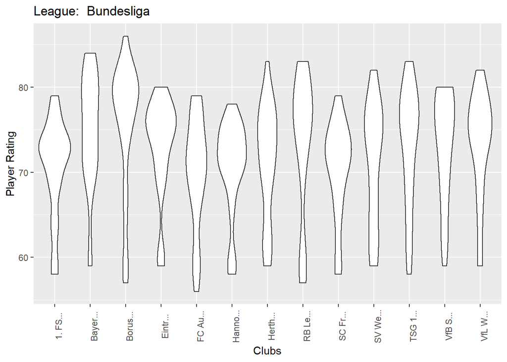

```r
library(ggplot2)

#Club team names on the x axis are shortened and angled to improve readability of the plots
for(var in unique(player_combined$Div)){
  print(ggplot(player_combined[player_combined$Div == var,],
               aes(x=factor(Club), y=Rating), color=club) +
                  geom_violin() +
                  scale_x_discrete(label=function(x) stringr::str_trunc(x, 8)) +
                  theme(axis.text.x = element_text(angle=90)) +
                  labs(title=paste("League: ", var), x="Clubs", y="Player Rating"))
}
```

We can also make a plot to see the overall player rating distribution for each league

- This plot uses a polygon distribution to represent the count of each rating
- The red line represents the median player rating for the league
- The blue lines represent (Median +- (1.5 * Inner Quartile Range)), or the threshold for outlying player ratings. Player ratings above or below the blue lines represent players that have extremely high or low player ratings related to their league.

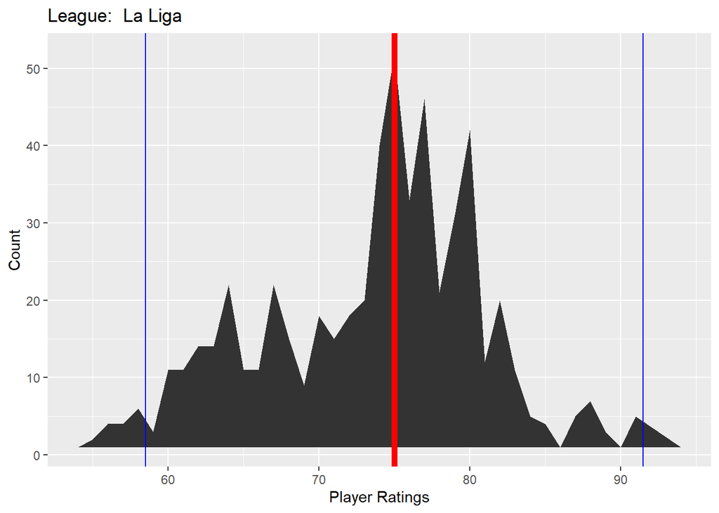

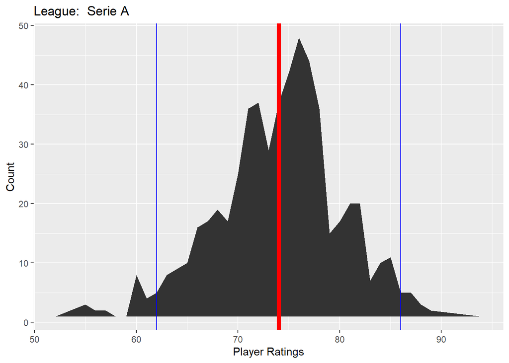

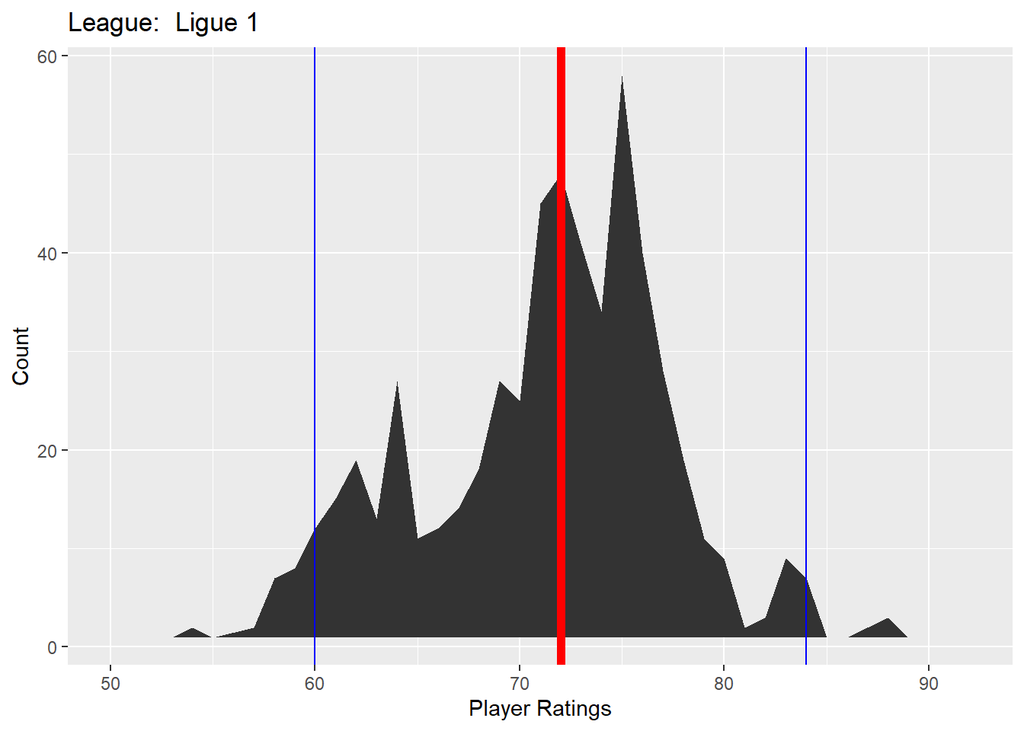

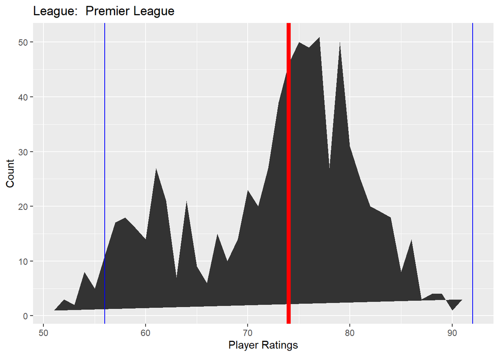

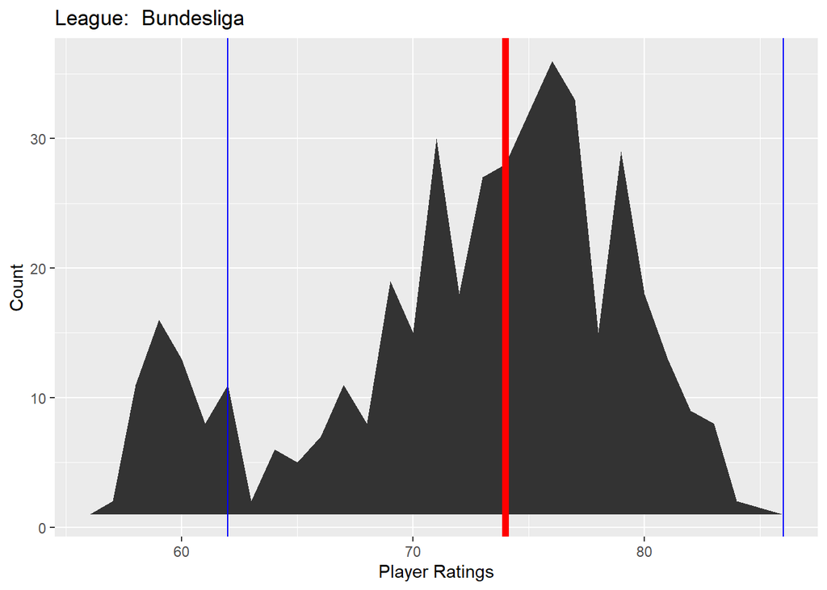

```r
#A plot is created for each of the 5 leagues, using vline to plot 3 lines representing lower outlier, median and higher outlier
for(var in unique(player_combined$Div)){
  median <- median(player_combined[player_combined$Div==var,]$Rating)
  iqr <- IQR(player_combined[player_combined$Div==var,]$Rating)
  rating_count <- count(player_combined[player_combined$Div==var,], Rating)

  print(rating_count %>% ggplot(aes(x=Rating, y=n)) +
                        geom_polygon() +
                        geom_vline(aes(xintercept=median), color="red", size=2) +
                        geom_vline(aes(xintercept = median+(1.5*iqr)), color = "blue") +
                        geom_vline(aes(xintercept = median-(1.5*iqr)), color = "blue") +
                        labs(title=paste("League: ", var), x="Player Ratings", y="Count"))
}
```

Finally, we can create a density plot to show all of the league’s player ratings side by side. This plot gives us a good idea of how FIFA ratings are distributed across different leagues

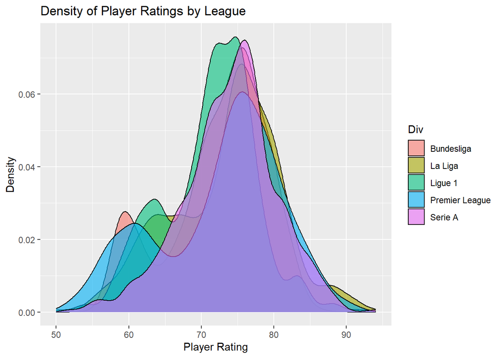

```r
counting <- count(player_combined, Rating)
factor <- factor(player_combined$Div)

player_combined %>% ggplot(aes(x=Rating, group=Div, fill=Div)) +
  geom_density(adjust=0.8, alpha=0.6) +
  labs(title="Density of Player Ratings by League", x="Player Rating", y="Density")
```

From these plots we can see that FIFA uses a similar distribution for it’s player ratings across leagues

- The majority of players have ratings within 70-80.
- There is a second smaller peak of player ratings around the 60’s
- All other players fall somewhere in between with some variety.

## Hypothesis Testing

Now that we have some idea of what our data looks like, let’s see if we can draw any relevant correlations.

We’ll start by seeing if there is any correlation between a player’s age and their player rating within FIFA.

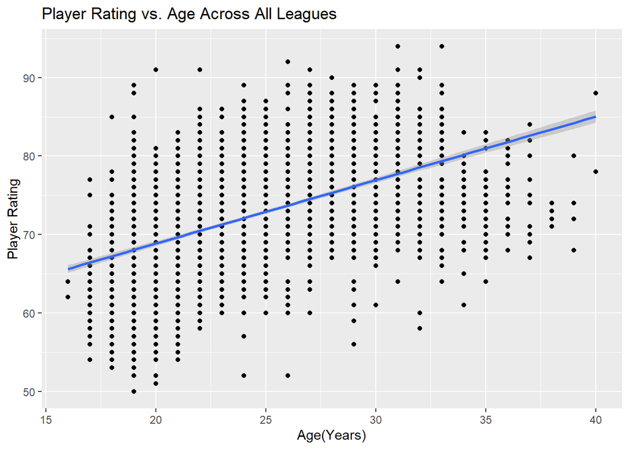

```r
library(broom)

player_combined %>% ggplot(aes(x=Age, y=Rating)) +
  geom_point() +
  geom_smooth(method=lm) +
  labs(title="Player Rating vs. Age Across All Leagues", x="Age(Years)", y="Player Rating")
```

```r
tidy(lm(Rating~Age, player_combined))
```

```
## # A tibble: 2 x 5
##   term        estimate std.error statistic   p.value
##   <chr>          <dbl>     <dbl>     <dbl>     <dbl>
## 1 (Intercept)   52.7      0.635       82.9 0.
## 2 Age            0.809    0.0252      32.1 8.73e-194
```

As we can see from the fitted linear model, There is a very clear correlation between player rating and player age. We know this because the p-value for the estimated rating coefficient is 8.727e-194, which is nearly 0. A p-value below .01 would be enough to prove that there is a statistically significant relationship between player rating and age. However, we can also see that a linear model is perhaps not the best model for this data. It seems parabolic rather than linear.

Next, we can test whether there is any correlation between player’s wages their rating.

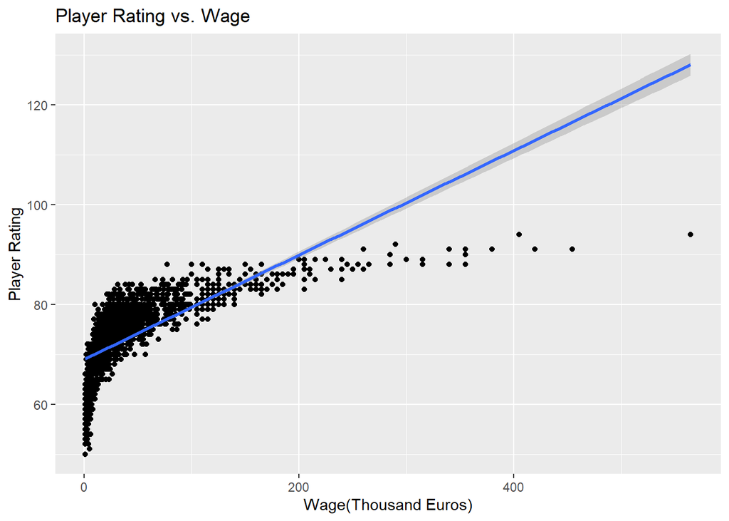

```r
player_combined %>% ggplot(aes(x=Wage, y=Rating)) +
  geom_point() +
  geom_smooth(method=lm) +
  labs(title="Player Rating vs. Wage", x="Wage(Thousand Euros)", y="Player Rating")
```

```r
tidy(lm(Rating~Wage, player_combined))
```

```
## # A tibble: 2 x 5
##   term        estimate std.error statistic p.value
##   <chr>          <dbl>     <dbl>     <dbl>   <dbl>
## 1 (Intercept)   69.0     0.125       551.        0
## 2 Wage           0.104   0.00212      49.4       0
```

When these variables are plotted linearly we can see that there is a very clear logarithmic relationship between player rating and wage. In order to see if we can better fit a model for these two variables we will now plot player rating vs. log(wage).

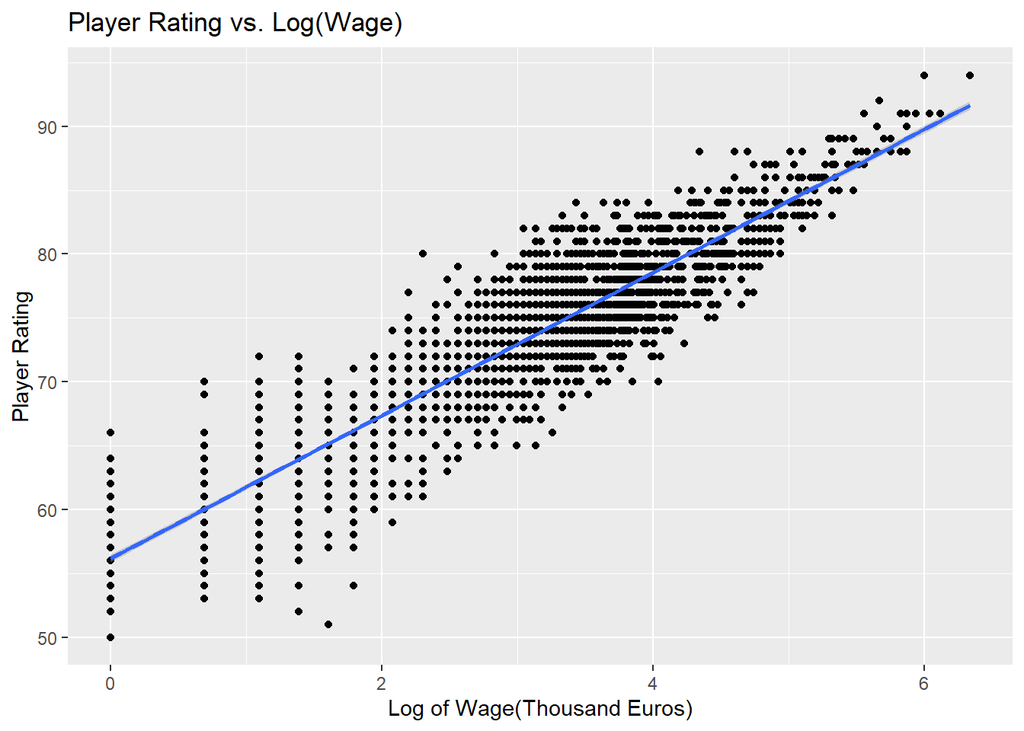

```r
player_combined %>% ggplot(aes(x=log(Wage), y=Rating)) +
  geom_point() +
  geom_smooth(method=lm) +
  labs(title="Player Rating vs. Log(Wage)", x="Log of Wage(Thousand Euros)", y="Player Rating")
```

```r
tidy(lm(Rating~log(Wage), player_combined))
```

```
## # A tibble: 2 x 5
##   term        estimate std.error statistic p.value
##   <chr>          <dbl>     <dbl>     <dbl>   <dbl>
## 1 (Intercept)    56.1     0.153       366.       0
## 2 log(Wage)       5.60    0.0481      116.       0
```

From both of these plots we can determine that there is also a clear correlation between player rating and wage. The p-value is 0 meaning that the estimate for the slope is statistically significant from 0 (or no correlation).

The last variables we will compare are real winning percentage and FIFA team ratings.

[figure not shown]

```r
team_combined %>% ggplot(aes(x=team_rating, y=perc)) +
  geom_point() +
  geom_smooth(method=lm) +
  labs(title="Team Winning Percentage vs. Team FIFA Rating", x="Team FIFA Rating", y="Season 18/19 Winning Percentage")
```

```r
tidy(lm(perc~team_rating, team_combined))
```

```
## # A tibble: 2 x 5
##   term        estimate std.error statistic  p.value
##   <chr>          <dbl>     <dbl>     <dbl>    <dbl>
## 1 (Intercept)  -216.      31.1       -6.94 7.49e-10
## 2 team_rating     3.66     0.428      8.56 4.64e-13
```

From this plot we can determine that there is a correlation between a team’s real winning percentage in the 18/19 season and their team rating on FIFA. The p-value is 4.644e-13. This means that the estimated coefficient is significantly different than 0 (no correlation).

## Machine Learning

Next, we will be creating a random forest model in order to see how well the winning percentages can be predicted based solely on the team ratings on FIFA. In order to perform this we need to randomly select 20 club/teams from our clean data. We will use these 20 clubs to train our random forest of 500 trees.

```r
library(randomForest)
library(pracma)
set.seed(654321)

#Create a new dataframe without Division and Club names
#Augument a column to represent row indices to help with sampling

ml_df <- team_combined %>%
  mutate(row_index = 0) %>%
  select(row_index, team_rating, perc)
for(row in 1:nrow(ml_df)){
  ml_df[row, "row_index"] = row
}

#Create the training set by taking 20 random rows

training_set <- ml_df[sample(nrow(ml_df), 20),]
sampled_indices <- as.vector(training_set$row_index)
training_set <- training_set %>%
  select(team_rating, perc)

#Create testing set by taking all rows not used in the training set.

testing_set <- ml_df[-sampled_indices,] %>%
  select(team_rating, perc)

#Train the random forest model using the training set data with 500 trees.

rf <- randomForest(
  perc~.,
  ntree=500,
  data=training_set
)

#This is the training set dataframe

head(training_set, 10)
```

```
## # A tibble: 10 x 2
##    team_rating  perc
##          <dbl> <dbl>
##  1        75.2  44.7
##  2        72.9  36.8
##  3        72.3  50
##  4        73.0  47.4
##  5        73    68.4
##  6        73.0  58.8
##  7        73.4  39.5
##  8        73.5  68.4
##  9        71.3  26.3
## 10        72.5  42.1
```

```r
#This is the testing set dataframe

head(testing_set, 10)
```

```
## # A tibble: 10 x 2
##    team_rating  perc
##          <dbl> <dbl>
##  1        70.8  41.2
##  2        69.1  39.5
##  3        75.2  65.8
##  4        72.6  63.2
##  5        73.8  50
##  6        69.9  36.8
##  7        70.9  34.2
##  8        70.8  42.1
##  9        68.2  31.6
## 10        71.1  23.7
```

Now we must use our model to predict winning percentages based on our testing set of team ratings. After we obtain our predictions, we can compare them to our real season winning percentages to identify how accurate our model is.

1. Create the output dataframe that contains the testing team ratings, win percentages, predicted win percentages, and the difference between the prediction and the actual value.
   - Also create a long dataframe that relates team rating to win percentage conditioned on whether its an actual value or a prediction. This will be helpful for plotting the data.

```r
#Create one column for the predicted win percentage and one column for the difference between the predicted and real win percentage

output <- testing_set %>%
  mutate(prediction = predict(rf, newdata=testing_set)) %>%
  mutate(difference = (prediction - perc))

#Creating a 3 column dataframe for just actual data

actual <- testing_set %>%
  mutate(datatype = "Actual") %>%
  select(datatype, team_rating, perc)

#Creating a 3 column dataframe for just prediction data

predicted <- testing_set %>%
  mutate(perc = predict(rf, newdata=testing_set)) %>%
  mutate(datatype = "Predicted") %>%
  select(datatype, team_rating, perc)

#Binding both the predicted and actual dataframes to be used for graphing

graphing <- rbind(actual, predicted)

#This is the full output dataframe

head(output, 10)
```

```
## # A tibble: 10 x 4
##    team_rating  perc prediction difference
##          <dbl> <dbl>      <dbl>      <dbl>
##  1        70.8  41.2       47.8       6.63
##  2        69.1  39.5       44.7       5.18
##  3        75.2  65.8       57.8      -8.00
##  4        72.6  63.2       42.8     -20.4
##  5        73.8  50         58.8       8.78
##  6        69.9  36.8       44.7       7.82
##  7        70.9  34.2       47.8      13.6
##  8        70.8  42.1       47.6       5.53
##  9        68.2  31.6       44.7      13.1
## 10        71.1  23.7       38.7      15.0
```

2. Let’s look at a plot of predicted and actual win percentages vs. team rating. Color key is provided on the right to show which line corresponds to which set of values

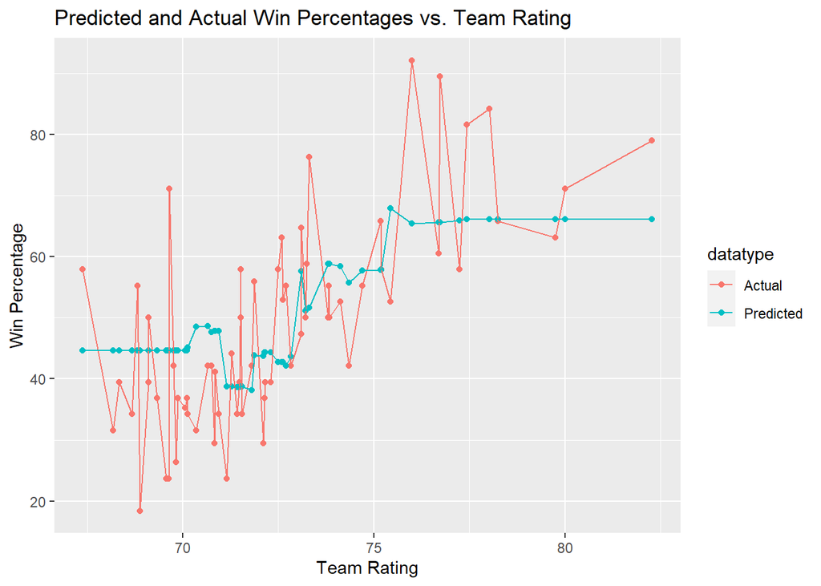

```r
#Plot both the prediction and actual values against team rating

graphing %>% ggplot(aes(x=team_rating, y=perc, color=datatype)) +
  geom_point() +
  geom_line() +
  labs(
    title="Predicted and Actual Win Percentages vs. Team Rating",
    x="Team Rating",
    y="Win Percentage"
  )
```

As we can see from the plot, the actual values of win percentage seem to be more sporadic whereas the predicted values are more even

3. Next lets look at a plot of predicted win percentage vs. actual win percentage

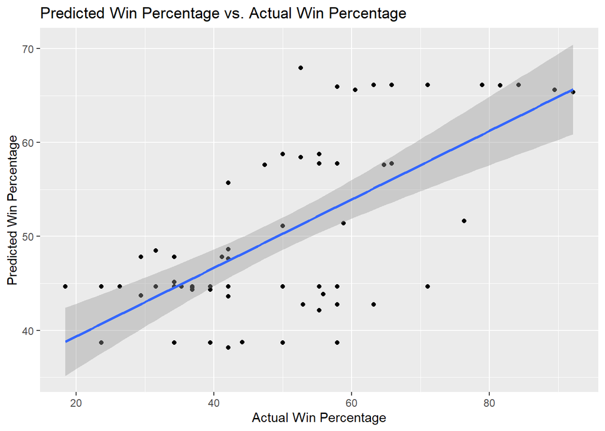

```r
output %>% ggplot(aes(x=perc, y=prediction)) +
  geom_point() +
  geom_smooth(method=lm) +
  labs(title="Predicted Win Percentage vs. Actual Win Percentage",
       x="Actual Win Percentage",
       y="Predicted Win Percentage"
  )
```

```r
tidy(lm(prediction~perc, output))
```

```
## # A tibble: 2 x 5
##   term        estimate std.error statistic  p.value
##   <chr>          <dbl>     <dbl>     <dbl>    <dbl>
## 1 (Intercept)   32.1      2.69       11.9  6.40e-18
## 2 perc           0.364    0.0520      7.01 1.78e- 9
```

It is important to note that if the predictions were 100% accurate the predicted and actual values would be identical. A 100% accurate predictive model would result in the slope of this graph being exactly 1. If the slope of the line was 1 this would mean that for every increase in actual win percentage there would be a mirrored increase in the predicted value.

However, we can see from the linear model that the slope is instead 0.3645. This means that the value of the predicted win percentage increases by 0.3645 percent for every 1 percent increase of actual win percentage. This means that the predictive model was not perfectly accurate.

It is also important to note, however, that the p-value for this slope coefficient estimate is 1.784e-9. So, while we did not get a perfect slope of 1, there is still a statistically significant direct correlation between actual and predicted value.

3. The last plot we can look at is a plot of differences between predicted and actual win percentages vs. team rating.

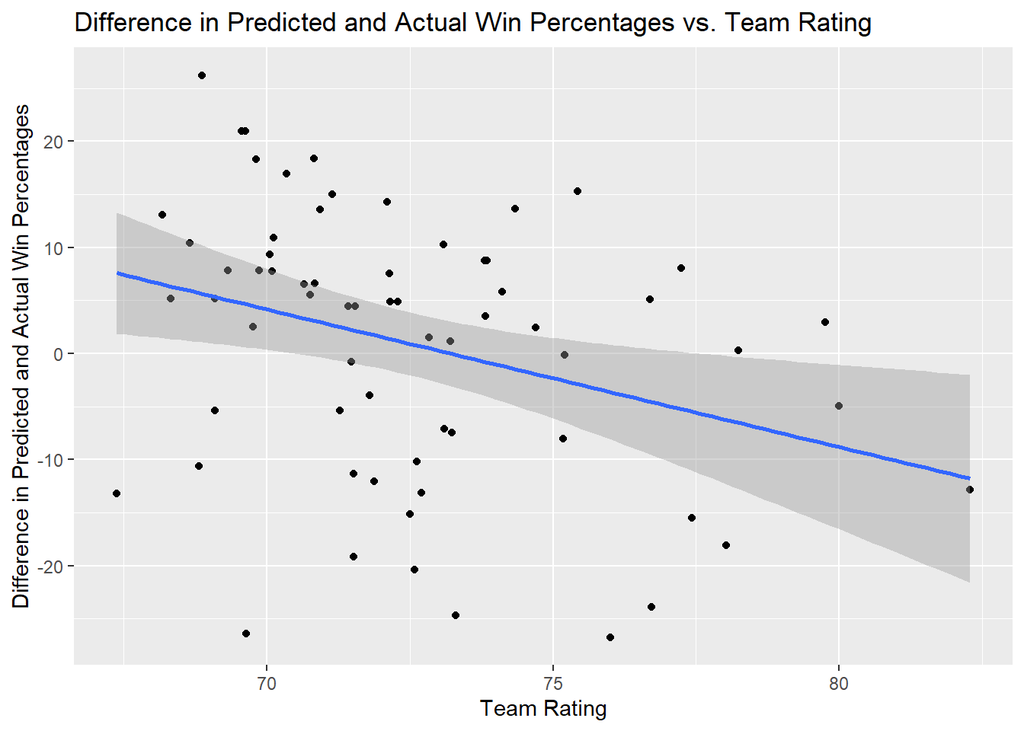

```r
output %>%
  ggplot(aes(x=team_rating, y=difference)) +
    geom_point() +
    geom_smooth(method=lm) +
    labs(
      title="Difference in Predicted and Actual Win Percentages vs. Team Rating",
      x="Team Rating",
      y="Difference in Predicted and Actual Win Percentages"
    )
```

A difference of 0 means that the predictive model was accurate. From this plot we can see that the predictive model is most accurate at a team rating of about 73. We can also see that it typically overestimates at lower team ratings and underestimates at higher team ratings.

4. The last step of analysis is performing a two-tailed t test for difference of means. The null hypothesis of this test is that there is no difference between the predicted and actual win percentages. The alternative hypothesis is that there is a difference between the predicted and actual win percentages. In order to prove that this predictive model works, we need to fail to reject the null hypothesis, because we do not want the two values to be statistically different from each other.

```r
t.test(output$perc, output$prediction)
```

```
##
##  Welch Two Sample t-test
##
## data:  output$perc and output$prediction
## t = -0.39628, df = 101.36, p-value = 0.6927
## alternative hypothesis: true difference in means is not equal to 0
## 95 percent confidence interval:
##  -5.562505  3.710072
## sample estimates:
## mean of x mean of y
##  49.02195  49.94817
```

From out two-tailed t-test we have obtained a p-value of 0.6927. This p-value is much too large to reject the null hypothesis. This means that since that we failed to reject the null hypothesis, the predicted win percentage and actual win percentage are not statistically different from one another.

## Conclusion

Video games and even following sports can sometimes be seen as a waste of time, but there is a lot of analytics and science that goes into them. Electronic Arts takes the time very year to evaluate player performance to finalize their ratings for the next FIFA game. The ratings are based on some true performances in the past, and can sometimes be a good indication towards how a team will perform in real life. A lot of people invest money and place bets on sports as a source of income, and it would be interesting if a team’s rating would dirrectly correlate to the winning percentage and help the betters out. Our model did have some success, but wasn’t always completely accurate. This could be due to the fact that we created a model with random teams from each league. If we handpicked some teams with high ratings, some with low ratings, and some with average ratings we might have had a more accurate model. This was interesting however, because we did find a positive correlation between a teams FIFA rating and their winning percentage, with a p-value of 4.644e-13. The slope of our actual vs predicted line was 0.3645, and if our model as perfect it should have been 1. The p-value was 1.784e-9, so even though are model wasn’t perfect we can declare that there is definitely some sort of positive correlation between a team’s FIFA rating and their real life winning percentage. Although overall FIFA rating takes into account a lot of players and skills, in the future it would be best to account for attacking rating, defending rating and maybe some other numbers to predict how each team would do against another based on the attacking, defending, and other soccer/football skills they possess. Sports science/mathematics is a very difficult topic because there are many upsets that can occur in the sports world based on a multitude of factors, like Leicester City in the 2015/2016 Premier League season. They won the Premier league after coming in 14th place out of 20 teams the previous year, and the year before that they were playing in the English Championship, which is like the second division or minor league. It isn’t always wise to trust the team with the better players or higher FIFA ratings to always do well. Our model got the general trend correct, in which a higher rated team would have a better winning percentage, but wasn’t able to predict the winning percentage exactly.